# Testing Graphical User Interfaces

In this chapter, we explore how to generate tests for Graphical User Interfaces (GUIs), abstracting from our previous examples on Web testing. Building on general means to extract user interface elements and activate them, our techniques generalize to arbitrary graphical user interfaces, from rich Web applications to mobile apps, and systematically explore user interfaces through forms and navigation elements.

**Prerequisites**

- We build on the Web server introduced in the chapter on Web testing.

## Synopsis

To use the code provided in this chapter, write

```
>>> from fuzzingbook.GUIFuzzer import <identifier>
```

and then make use of the following features.

**Note**: The examples in this section only work after the rest of the cells have been executed.

The function `start_webdriver()` starts a headless Web browser in the background and returns a *GUI driver* as handle for further communication.

```python
gui_driver = start_webdriver()
```

```
The geckodriver version (0.34.0) detected in PATH at /Users/zeller/bin/geckodriver might not be compatible with the detected firefox version (144.09); currently, geckodriver 0.36.0 is recommended for firefox 144.*, so it is advised to delete the driver in PATH and retry
```

We let the browser open the URL of the server we want to investigate (in this case, the vulnerable server from the chapter on Web fuzzing) and obtain a screenshot.

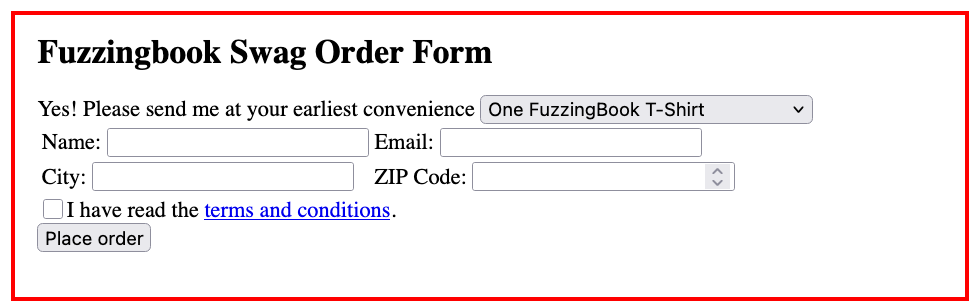

```python
gui_driver.get(httpd_url)
Image(gui_driver.get_screenshot_as_png())
```

The `GUICoverageFuzzer` class explores the user interface and builds a *grammar* that encodes all states as well as the user interactions required to move from one state to the next. It is paired with a `GUIRunner` which interacts with the GUI driver.

```python
gui_fuzzer = GUICoverageFuzzer(gui_driver)
```

```python
gui_runner = GUIRunner(gui_driver)
```

The `explore_all()` method extracts all states and all transitions from a Web user interface.

```python
gui_fuzzer.explore_all(gui_runner)
```

The grammar embeds a finite state automation and is best visualized as such.

```python
fsm_diagram(gui_fuzzer.grammar)
```

[output not shown]

[output cut: 69 more lines]

[output not shown]

```
<graphviz.graphs.Digraph at 0x1132cb570>
```

```python
gui_driver.get(httpd_url)
actions = gui_fuzzer.fuzz()
print(actions)
```

```
click('terms and conditions')
```

These actions can be fed into the GUI runner, which will execute them on the given GUI driver.

```python
gui_driver.get(httpd_url)
result, outcome = gui_runner.run(actions)
```

```python
Image(gui_driver.get_screenshot_as_png())
```

[output not shown]

Further invocations of `fuzz()` will further cover the model – for instance, exploring the terms and conditions.

Internally, `GUIFuzzer` and `GUICoverageFuzzer` use a subclass `GUIGrammarMiner` which implements the analysis of the GUI and all its states. Subclassing `GUIGrammarMiner` allows extending the interpretation of GUIs; the `GUIFuzzer` constructor allows passing a miner via the `miner` keyword parameter.

A tool like `GUICoverageFuzzer` will provide "deep" exploration of user interfaces, even filling out forms to explore what is behind them. Keep in mind, though, that `GUICoverageFuzzer` is experimental: It only supports a subset of HTML form and link features, and does not take JavaScript into account.

```python
# ignore
from ClassDiagram import display_class_hierarchy
from Fuzzer import Fuzzer, Runner
from Grammars import Grammar, Expansion
from GrammarFuzzer import GrammarFuzzer, DerivationTree
```

```python
# ignore
display_class_hierarchy([GUIFuzzer, GUICoverageFuzzer,
                         GUIRunner, GUIGrammarMiner],
                        public_methods=[
                            Fuzzer.__init__,
                            Fuzzer.fuzz,
                            Fuzzer.run,
                            Fuzzer.runs,
                            Runner.__init__,
                            Runner.run,
                            GUIRunner.__init__,
                            GUIRunner.run,
                            GrammarFuzzer.__init__,
                            GrammarFuzzer.fuzz,
                            GrammarFuzzer.fuzz_tree,
                            GUIFuzzer.__init__,
                            GUIFuzzer.restart,
                            GUIFuzzer.run,
                            GUIGrammarMiner.__init__,
                            GrammarCoverageFuzzer.__init__,
                            GUICoverageFuzzer.__init__,
                            GUICoverageFuzzer.explore_all,
                        ],
                        types={
                            'DerivationTree': DerivationTree,
                            'Expansion': Expansion,
                            'Grammar': Grammar
                        },
                        project='fuzzingbook')
```

[output not shown]

[output cut: 69 more lines]

[output not shown]

[output not shown]

[output cut: 62 more lines]

[output not shown]

```
<graphviz.graphs.Digraph at 0x113e80950>
```

## Automated GUI Interaction

In this chapter, we therefore take a different approach to user interface testing. Rather than using HTTP and HTML as the mechanisms for interaction, we leverage a dedicated *UI testing framework*, which allows us to

- query the program under test for available user interface elements, and
- query the UI elements for how they can be interacted with.

Although we will again illustrate our approach using a Web server, the approach easily generalizes to *arbitrary user interfaces*. In fact, the UI testing framework we use, *Selenium*, also comes in variants that run for Android apps.

### Our Web Server, Again

As in the chapter on Web testing, we run a Web server that allows us to order products.

```python
# ignore
if 'CI' in os.environ:
    # Can't run this in our continuous environment,
    # since it can't run a headless Web browser
    sys.exit(0)
```

```python
db = init_db()
```

This is the address of our web server:

```python
httpd_process, httpd_url = start_httpd()
print_url(httpd_url)
```

```
http://127.0.0.1:8800
```

Using `webbrowser()`, we can retrieve the HTML of the home page, and use `HTML()` to render it.

```python
HTML(webbrowser(httpd_url))
```

```
127.0.0.1 - - [26/Oct/2025 14:35:26] "GET / HTTP/1.1" 200 -
```

**Fuzzingbook Swag Order Form**

Yes! Please send me at your earliest convenience

| Name: | Email: |
| --- | --- |
| City: | ZIP Code: |

I have read the terms and conditions.

### Remote Control with Selenium

Let us take a look at the GUI above. In contrast to the chapter on Web testing, we do not assume we can access the HTML source of the current page. All we assume is that there is a set of *user interface elements* we can interact with.

[Selenium](https://www.seleniumhq.org) is a framework for testing Web applications by *automating interaction in the browser*. Selenium provides an API that allows one to launch a Web browser, query the state of the user interface, and interact with individual user interface elements. The Selenium API is available in a number of languages; we use the [Selenium API for Python](https://selenium-python.readthedocs.io/index.html).

A Selenium *web driver* is the interface between a program and a browser controlled by the program. The following code starts a Web browser in the background, which we then control through the web driver.

We support both Firefox and Google Chrome.

```python
BROWSER = 'firefox'  # Set to 'chrome' if you prefer Chrome
```

#### Setting up Firefox

For Firefox, you have to make sure the [geckodriver program](https://github.com/mozilla/geckodriver/releases) is in your path.

```python
if BROWSER == 'firefox':
    assert shutil.which('geckodriver') is not None, \
        "Please install the 'geckodriver' executable " \
        "from https://github.com/mozilla/geckodriver/releases"
```

#### Setting up Chrome

For Chrome, you may have to make sure the [chromedriver program](https://chromedriver.chromium.org) is in your path.

```python
if BROWSER == 'chrome':
    assert shutil.which('chromedriver') is not None, \
        "Please install the 'chromedriver' executable " \
        "from https://chromedriver.chromium.org"
```

#### Running a Headless Browser

The browser is *headless*, meaning that it does not show on the screen.

```python
HEADLESS = True
```

**Note**: If the notebook server runs locally (i.e. on the same machine on which you are seeing this), you can also set `HEADLESS` to `False` and see what happens right on the screen as you execute the notebook cells. This is very much recommended for interactive sessions.

#### Starting the Web driver

This code starts the Selenium web driver.

```python
def start_webdriver(browser=BROWSER, headless=HEADLESS, zoom=1.4):
    # Set headless option
    if browser == 'firefox':
        options = webdriver.FirefoxOptions()
        if headless:
            # See https://www.browserstack.com/guide/firefox-headless
            options.add_argument("--headless")
    elif browser == 'chrome':
        options = webdriver.ChromeOptions()
        if headless:
            # See https://www.selenium.dev/blog/2023/headless-is-going-away/
            options.add_argument("--headless=new")
    else:
        assert False, "Select 'firefox' or 'chrome' as browser"

    # Start the browser, and obtain a _web driver_ object such that we can interact with it.
    if browser == 'firefox':
        # For firefox, set a higher resolution for our screenshots
        options.set_preference("layout.css.devPixelsPerPx", repr(zoom))
        gui_driver = webdriver.Firefox(options=options)

        # We set the window size such that it fits our order form exactly;
        # this is useful for not wasting too much space when taking screen shots.
        gui_driver.set_window_size(700, 300)

    elif browser == 'chrome':
        gui_driver = webdriver.Chrome(options=options)
        gui_driver.set_window_size(700, 210 if headless else 340)

    return gui_driver
```

```python
gui_driver = start_webdriver(browser=BROWSER, headless=HEADLESS)
```

```
The geckodriver version (0.34.0) detected in PATH at /Users/zeller/bin/geckodriver might not be compatible with the detected firefox version (144.09); currently, geckodriver 0.36.0 is recommended for firefox 144.*, so it is advised to delete the driver in PATH and retry
```

We can now interact with the browser programmatically. First, we have it navigate to the URL of our Web server:

```python
gui_driver.get(httpd_url)
```

We see that the home page is actually accessed, together with a (failing) request to get a page icon:

```python
print_httpd_messages()
```

```
127.0.0.1 - - [26/Oct/2025 14:36:01] "GET / HTTP/1.1" 200 -
```

```
127.0.0.1 - - [26/Oct/2025 14:36:01] "GET /favicon.ico HTTP/1.1" 404 -
```

To see what the "headless" browser displays, we can obtain a screenshot. We see that it actually displays the home page.

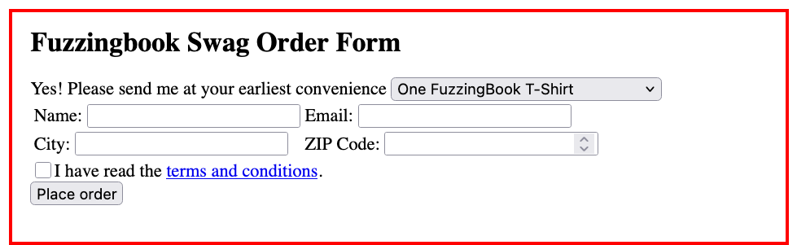

```python
Image(gui_driver.get_screenshot_as_png())
```

### Filling out Forms

To interact with the Web page through Selenium and the browser, we can *query* Selenium for individual elements. For instance, we can access the UI element whose `name` attribute (as defined in HTML) is `"name"`.

```python
name = gui_driver.find_element(By.NAME, "name")
```

Once we have an element, we can interact with it. Since `name` is a text field, we can send it a string using the `send_keys()` method; the string will be translated into appropriate keystrokes.

```python
name.send_keys("Jane Doe")
```

In the screenshot, we can see that the `name` field is now filled:

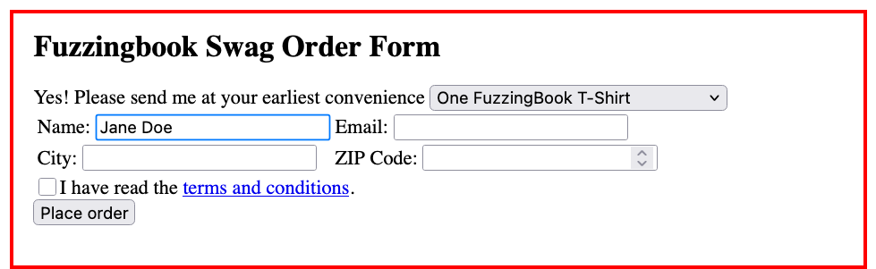

```python
Image(gui_driver.get_screenshot_as_png())
```

Similarly, we can fill out the email, city, and ZIP fields:

```python
email = gui_driver.find_element(By.NAME, "email")
email.send_keys("j.doe@example.com")
```

```python
city = gui_driver.find_element(By.NAME, 'city')
city.send_keys("Seattle")
```

```python
zip = gui_driver.find_element(By.NAME, 'zip')
zip.send_keys("98104")
```

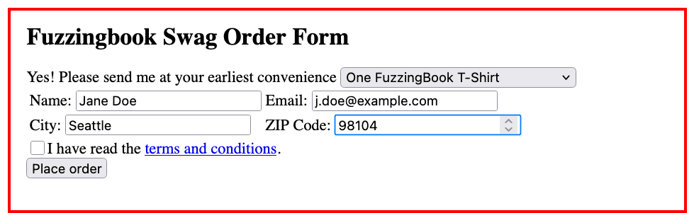

```python
Image(gui_driver.get_screenshot_as_png())
```

The check box for terms and conditions is not filled out, but clicked instead using the `click()` method.

```python
terms = gui_driver.find_element(By.NAME, 'terms')
terms.click()
```

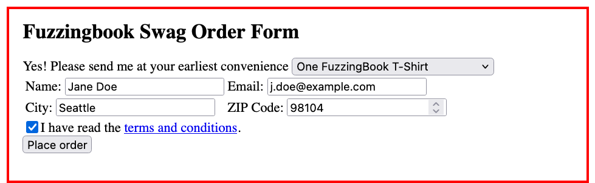

```python
Image(gui_driver.get_screenshot_as_png())
```

The form is now fully filled out. By clicking on the `submit` button, we can place the order:

```python
submit = gui_driver.find_element(By.NAME, 'submit')
submit.click()
```

We see that the order is being processed, and that the Web browser has switched to the confirmation page.

```python
print_httpd_messages()
```

```
127.0.0.1 - - [26/Oct/2025 14:36:02] INSERT INTO orders VALUES ('tshirt', 'Jane Doe', 'j.doe@example.com', 'Seattle', '98104')
```

```
127.0.0.1 - - [26/Oct/2025 14:36:02] "GET /order?item=tshirt&name=Jane+Doe&email=j.doe%40example.com&city=Seattle&zip=98104&terms=on&submit=Place+order HTTP/1.1" 200 -
```

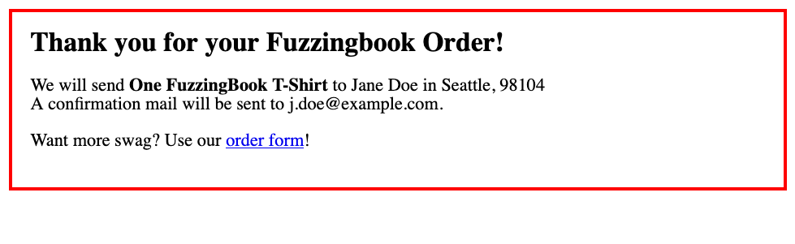

```python
Image(gui_driver.get_screenshot_as_png())
```

### Navigating

Just as we fill out forms, we can also navigate through a website by clicking on links. Let us go back to the home page:

```python
gui_driver.back()
```

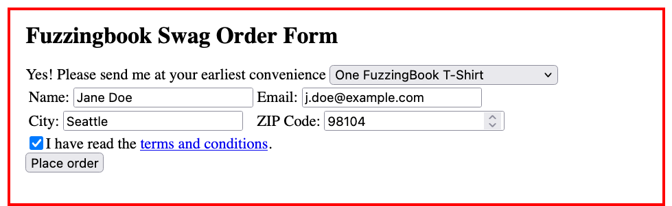

```python
Image(gui_driver.get_screenshot_as_png())
```

We can query the web driver for all elements of a particular type. Querying for HTML anchor elements (`<a>`) for instance, gives us all links on a page.

```python
links = gui_driver.find_elements(By.TAG_NAME, "a")
```

We can query the attributes of UI elements – for instance, the URL the first anchor on the page links to:

```python
links[0].get_attribute('href')
```

```
'http://127.0.0.1:8800/terms'
```

What happens if we click on it? Very simple: We switch to the Web page being referenced.

```python
links[0].click()
```

```python
print_httpd_messages()
```

```
127.0.0.1 - - [26/Oct/2025 14:36:02] "GET /terms HTTP/1.1" 200 -
```

```python
Image(gui_driver.get_screenshot_as_png())
```

[output not shown]

Okay. Let's get back to our home page again.

```python
gui_driver.back()
```

```python
print_httpd_messages()
```

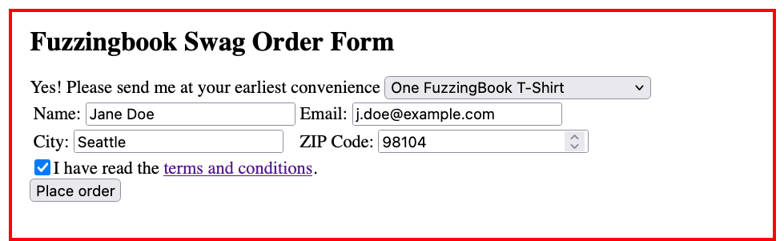

```python
Image(gui_driver.get_screenshot_as_png())
```

### Writing Test Cases

The above calls, interacting with a user interface automatically, are typically used in *Selenium tests* – that is, code snippets that interact with a website, occasionally checking whether everything works as expected. The following code, for instance, places an order just as above. It then retrieves the `title` element and checks whether the title contains a "Thank you" message, indicating success.

```python
def test_successful_order(driver, url):
    name = "Walter White"
    email = "white@jpwynne.edu"
    city = "Albuquerque"
    zip_code = "87101"

    driver.get(url)
    driver.find_element(By.NAME, "name").send_keys(name)
    driver.find_element(By.NAME, "email").send_keys(email)
    driver.find_element(By.NAME, 'city').send_keys(city)
    driver.find_element(By.NAME, 'zip').send_keys(zip_code)
    driver.find_element(By.NAME, 'terms').click()
    driver.find_element(By.NAME, 'submit').click()

    title = driver.find_element(By.ID, 'title')
    assert title is not None
    assert title.text.find("Thank you") >= 0

    confirmation = driver.find_element(By.ID, "confirmation")
    assert confirmation is not None

    assert confirmation.text.find(name) >= 0
    assert confirmation.text.find(email) >= 0
    assert confirmation.text.find(city) >= 0
    assert confirmation.text.find(zip_code) >= 0

    return True
```

```python
test_successful_order(gui_driver, httpd_url)
```

```
True
```

In a similar vein, we can set up automated test cases for unsuccessful orders, canceling orders, changing orders, and many more. All these test cases would be automatically run after any change to the program code, ensuring the Web application still works.

Of course, writing such tests is quite some effort. Hence, in the remainder of this chapter, we will again explore how to automatically generate them.

## Retrieving User Interface Actions

To automatically interact with a user interface, we first need to find out which elements there are, and which user interactions (or short *actions*) they support.

### User Interface Elements

We start with finding available user elements. Let us get back to the order form.

```python
gui_driver.get(httpd_url)
```

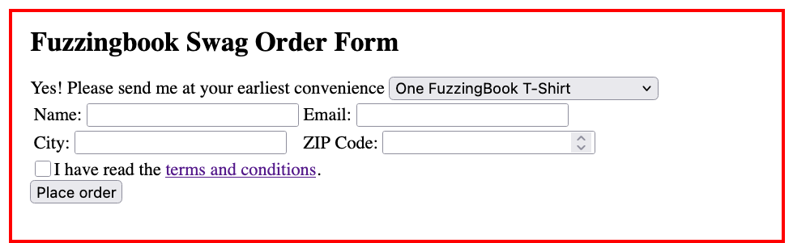

```python
Image(gui_driver.get_screenshot_as_png())
```

Using `find_elements(By.TAG_NAME, )` (and other similar `find_elements_...()` functions), we can retrieve all elements of a particular type, such as HTML `input` elements.

```python
ui_elements = gui_driver.find_elements(By.TAG_NAME, "input")
```

For each element, we can retrieve its HTML attributes, using `get_attribute()`. We can thus retrieve the `name` and `type` of each input element (if defined).

```python
for element in ui_elements:
    print("Name: %-10s | Type: %-10s | Text: %s" %
          (element.get_attribute('name'),
           element.get_attribute('type'),
           element.text))
```

```
Name: name       | Type: text       | Text:
Name: email      | Type: email      | Text:
Name: city       | Type: text       | Text:
Name: zip        | Type: number     | Text:
Name: terms      | Type: checkbox   | Text:
Name: submit     | Type: submit     | Text:
```

```python
ui_elements = gui_driver.find_elements(By.TAG_NAME, "a")
```

```python
for element in ui_elements:
    print("Name: %-10s | Type: %-10s | Text: %s" %
          (element.get_attribute('name'),
           element.get_attribute('type'),
           element.text))
```

```
Name:            | Type:            | Text: terms and conditions
```

### User Interface Actions

Similarly to what we did in the chapter on Web fuzzing, our idea is now to mine a *grammar* for the user interface – first for an individual user interface *page* (i.e., a single Web page), later for all pages offered by the application. The idea is that a grammar defines *legal sequences of actions* – clicks and keystrokes – that can be applied on the application.

We assume the following actions:

1. `fill(<name>, <text>)` – fill the UI input element named `<name>` with the text `<text>`.
2. `check(<name>, <value>)` – set the UI checkbox `<name>` to the given value `<value>` (True or False)
3. `submit(<name>)` – submit the form by clicking on the UI element `<name>`.
4. `click(<name>)` – click on the UI element `<name>`, typically for following a link.

This sequence of actions, for instance would fill out the order form:

```
fill('name', "Walter White")
fill('email', "white@jpwynne.edu")
fill('city', "Albuquerque")
fill('zip', "87101")
check('terms', True)
submit('submit')
```

Our set of actions is deliberately defined to be small – for real user interfaces, one would also have to define interactions such as swipes, double clicks, long clicks, right button clicks, modifier keys, and more. Selenium supports all of this; but in the interest of simplicity, we focus on the most important set of interactions.

### Retrieving Actions

As a first step in mining an action grammar, we need to be able to retrieve possible interactions. We introduce a class `GUIGrammarMiner`, which is set to do precisely that.

```python
class GUIGrammarMiner:
    """Retrieve a grammar of possible GUI interaction sequences"""

    def __init__(self, driver, stay_on_host: bool = True) -> None:
        """Constructor.
        `driver` - a web driver as produced by Selenium.
        `stay_on_host` - if True (default), no not follow links to other hosts.
        """
        self.driver = driver
        self.stay_on_host = stay_on_host
        self.grammar: Grammar = {}
```

Let us show `GUIGrammarMiner` in action, using its `mine_state_actions()` method to retrieve all elements from our current page. We see that we obtain input element actions, button element actions, and link element actions.

```python
gui_grammar_miner = GUIGrammarMiner(gui_driver)
gui_grammar_miner.mine_state_actions()
```

```
frozenset({"check('terms', <boolean>)",
           "click('terms and conditions')",
           "fill('city', '<text>')",
           "fill('email', '<email>')",
           "fill('name', '<text>')",
           "fill('zip', '<number>')",
           "submit('submit')"})
```

We assume that we can identify a user interface *state* from the set of interactive elements it contains – that is, the current Web page is identified by the set above. This is in contrast to Web fuzzing, where we assumed the URL to uniquely characterize a page – but with JavaScript, the URL can stay unchanged although the page contents change, and UIs other than the Web may have no concept of unique URLs. Therefore, we say that the way a UI can be interacted with uniquely defines its state.

## Models for User Interfaces

### User Interfaces as Finite State Machines

Now that we can retrieve UI elements from a page, let us go and systematically explore a user interface. The idea is to represent the user interface as a *finite state machine* – that is, a sequence of *states* that can be reached by interacting with the individual user interface elements.

Let us illustrate such a finite state machine by looking at our Web server. The following diagram shows the states our server can be in:

```python
# ignore
from graphviz import Digraph
```

```python
# ignore
from GrammarFuzzer import dot_escape
```

```python
# ignore
dot = Digraph(comment="Finite State Machine")
dot.node(dot_escape('<start>'))
dot.edge(dot_escape('<start>'),
         dot_escape('<Order Form>'))
dot.edge(dot_escape('<Order Form>'),
         dot_escape('<Terms and Conditions>'), "click('Terms and conditions')")
dot.edge(dot_escape('<Order Form>'),
         dot_escape('<Thank You>'), r"fill(...)\lsubmit('submit')")
dot.edge(dot_escape('<Terms and Conditions>'),
         dot_escape('<Order Form>'), "click('order form')")
dot.edge(dot_escape('<Thank You>'),
         dot_escape('<Order Form>'), "click('order form')")
display(dot)
```

[figure not shown]

Initially, we are in the `<Order Form>` state. From here, we can click on `Terms and Conditions`, and we'll be in the `Terms and Conditions` state, showing the page with the same title. We can also fill out the form and place the order, having us end in the `Thank You` state (again showing the page with the same title). From both `<Terms and Conditions>` and `<Thank You>`, we can return to the order form by clicking on the `order form` link.

### State Machines as Grammars

To systematically explore a user interface, we must retrieve its finite state machine, and eventually cover all states and transitions. In the presence of forms, such an exploration is difficult, as we need a special mechanism to fill out forms and submit the values to get to the next state. There is a trick, though, which allows us to have a single representation for both states and (form) values. We can *embed the finite state machine into a grammar*, which is then used for both states and form values.

To embed a finite state machine into a grammar, we proceed as follows:

1. Every *state* $\langle s \rangle$ in the finite state machine becomes a *symbol* $\langle s \rangle$ in the grammar.
2. Every *transition* in the finite state machine from $\langle s \rangle$ to $\langle t \rangle$ and actions $a_1, a_2, \dots$ becomes an *alternative* of $\langle s \rangle$ in the form $a_1, a_2, dots$ $\langle t \rangle$ in the grammar.

The above finite state machine thus gets encoded into the grammar

```
<start> ::= <Order Form>
<Order Form> ::= click('Terms and Conditions') <Terms and Conditions> |
                 fill(...) submit('submit') <Thank You>
<Terms and Conditions> ::= click('order form') <Order Form>
<Thank You> ::= click('order form') <Order Form>
```

Expanding this grammar gets us a stream of actions, navigating through the user interface:

```
fill(...) submit('submit') click('order form') click('Terms and Conditions') click('order form') ...
```

This stream is actually *infinite* (as one can interact with the UI forever); to have it end, one can introduce an alternative `<end>` that simply expands to the empty string, without having any expansion (state) follow.

### Retrieving State Grammars

Let us extend `GUIGrammarMiner` such that it retrieves a grammar from the user interface in its *current state*.

Let us show `GUIGrammarMiner()` in action. Its method `mine_state_grammar()` extracts the grammar for the current Web page:

```python
gui_grammar_miner = GUIGrammarMiner(gui_driver)
state_grammar = gui_grammar_miner.mine_state_grammar()
```

```python
state_grammar
```

```
{'<start>': ['<state>'],
 '<unexplored>': [''],
 '<end>': [''],
 '<text>': ['<string>'],
 '<string>': ['<character>', '<string><character>'],
 '<character>': ['<letter>', '<digit>', '<special>'],
 '<letter>': ['a',
  'b',
  'c',
  'd',
  'e',
  'f',
  'g',
  'h',
  'i',
  'j',
  'k',
  'l',
  'm',
  'n',
  'o',
  'p',
  'q',
  'r',
  's',
  't',
  'u',
  'v',
  'w',
  'x',
  'y',
  'z',
  'A',
  'B',
  'C',
  'D',
  'E',
  'F',
  'G',
  'H',
```

[output cut: 15 more lines]

```
  'X',
  'Y',
  'Z'],
 '<number>': ['<digits>'],
 '<digits>': ['<digit>', '<digits><digit>'],
 '<digit>': ['0', '1', '2', '3', '4', '5', '6', '7', '8', '9'],
 '<special>': ['.', ' ', '!'],
 '<email>': ['<letters>@<letters>'],
 '<letters>': ['<letter>', '<letters><letter>'],
 '<boolean>': ['True', 'False'],
 '<state>': ["click('terms and conditions')\n<state-1>",
  "fill('email', '<email>')\ncheck('terms', <boolean>)\nfill('zip', '<number>')\nfill('name', '<text>')\nfill('city', '<text>')\nsubmit('submit')\n<state-2>",
  '<end>'],
 '<state-1>': ['<unexplored>'],
 '<state-2>': ['<unexplored>']}
```

To better see the structure of the state grammar, we can visualize it as a state machine. We see that it nicely reflects what we can see from our Web server's home page:

```python
fsm_diagram(state_grammar)
```

[figure not shown]

From the start state (`<state>`), we can go and either click on "terms and conditions", ending in `<state-1>`, or fill out the form, ending in `<state-2>`.

```python
state_grammar[GUIGrammarMiner.START_STATE]
```

```
["click('terms and conditions')\n<state-1>",
 "fill('email', '<email>')\ncheck('terms', <boolean>)\nfill('zip', '<number>')\nfill('name', '<text>')\nfill('city', '<text>')\nsubmit('submit')\n<state-2>",
 '<end>']
```

Both these states are yet unexplored:

```python
state_grammar['<state-1>']
```

```
['<unexplored>']
```

```python
state_grammar['<state-2>']
```

```
['<unexplored>']
```

```python
state_grammar['<unexplored>']
```

```
['']
```

Given the grammar, we can use any of our grammar fuzzers to create valid input sequences:

```python
gui_fuzzer = GrammarFuzzer(state_grammar)
while True:
    action = gui_fuzzer.fuzz()
    if action.find('submit(') > 0:
        break
print(action)
```

```
fill('email', 'G@C')
check('terms', True)
fill('zip', '342')
fill('name', '.')
fill('city', '6')
submit('submit')
```

These actions, however, must also be *executed* such that we can explore the user interface. This is what we do in the next section.

### Executing User Interface Actions

To execute actions, we introduce a `Runner` class, conveniently named `GUIRunner`. Its `run()` method executes the actions as given in an action string.

```python
class GUIRunner(Runner):
    """Execute the actions in a given action string"""

    def __init__(self, driver) -> None:
        """Constructor. `driver` is a Selenium Web driver"""
        self.driver = driver
```

Let us try out `GUIRunner` and its `run()` method. We create a runner on our Web server, and let it execute a `fill()` action:

```python
gui_driver.get(httpd_url)
```

```python
gui_runner = GUIRunner(gui_driver)
```

```python
gui_runner.run("fill('name', 'Walter White')")
```

```
("fill('name', 'Walter White')", 'PASS')
```

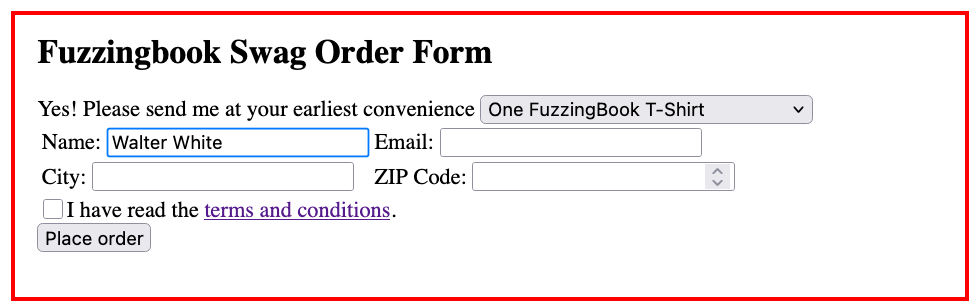

```python
Image(gui_driver.get_screenshot_as_png())
```

A `submit()` action submits the order. (Note that our Web server does no effort whatsoever to validate the form.)

```python
gui_runner.run("submit('submit')")
```

```
("submit('submit')", 'PASS')
```

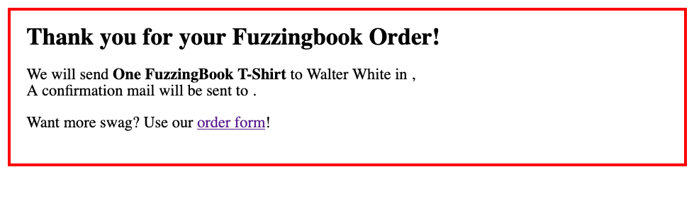

```python
Image(gui_driver.get_screenshot_as_png())
```

Of course, we can also execute action sequences generated from the grammar. This allows us to fill the form again and again, using values matching the type given in the form.

```python
gui_driver.get(httpd_url)
```

```python
gui_fuzzer = GrammarFuzzer(state_grammar)
```

```python
while True:
    action = gui_fuzzer.fuzz()
    if action.find('submit(') > 0:
        break
```

```python
print(action)
```

```
fill('email', 'HTrX@b')
check('terms', False)
fill('zip', '54')
fill('name', '.')
fill('city', '!')
submit('submit')
```

```python
gui_runner.run(action)
```

```
("fill('email', 'HTrX@b')\ncheck('terms', False)\nfill('zip', '54')\nfill('name', '.')\nfill('city', '!')\nsubmit('submit')\n",
 'PASS')
```

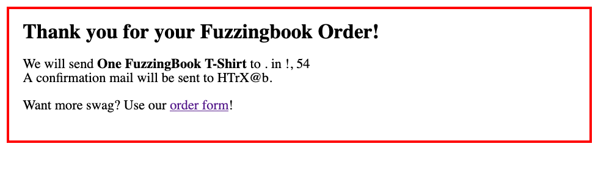

```python
Image(gui_driver.get_screenshot_as_png())
```

## Exploring User Interfaces

So far, our grammar retrieval and execution of actions is limited to the current user interface state (i.e., the current page shown). To systematically explore a user interface, we must explore all states, notably those ending in `<unexplored>` – and whenever we reach a new state, again retrieve its grammar such that we may be able to reach other states. Since some states can only be reached by generating inputs, test generation and user interface exploration *take place at the same time.*

Consequently, we introduce a `GUIFuzzer` class, which generates inputs for all forms and follows all links, and which updates its grammar (i.e., its user interface model as a finite state machine) every time it encounters a new state.

Let us put `GUIFuzzer` to use, enabling its logging mechanisms to see what it is doing.

```python
gui_driver.get(httpd_url)
```

```python
gui_fuzzer = GUIFuzzer(gui_driver, log_gui_exploration=True, disp_gui_exploration=True)
```

Running it the first time yields a new state:

```
Action fill('email', 'BU@L')
check('terms', False)
fill('zip', '1')
fill('name', '. 1')
fill('city', '1')
submit('submit') -> <state-2>
```

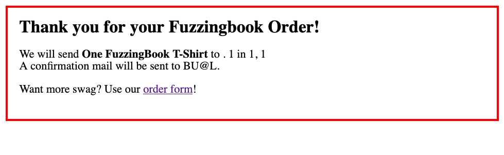

```
In new state <state-2> frozenset({"click('order form')"})
```

[figure not shown]

```
None
```

```
('<state-2>', 'PASS')
```

```python
gui_fuzzer.run(gui_runner)
```

```python
gui_fuzzer.run(gui_runner)
```

```
Action click('terms and conditions') -> <state-1>
```

```
In new state <state-1> frozenset({"click('order form')", "ignore('Creative Commons Attribution-NonCommercial-ShareAlike 4.0 International License.')"})
```

[figure not shown]

```
None
```

```
('<state-1>', 'PASS')
```

```python
gui_fuzzer.run(gui_runner)
```

```
Action click('terms and conditions') -> <end>
```

```
('<end>', 'PASS')
```

At this point, our GUI model is fairly complete already. In order to systematically cover *all* states, random exploration is not efficient enough, though.

## Covering States

During exploration as well as during testing, we want to *cover* all states and transitions between states. How can we achieve this?

It turns out that *we already have this.* Our `GrammarCoverageFuzzer` from the chapter on coverage-based grammar testing strives to systematically *cover all expansion alternatives* in a grammar. In the finite state model, these expansion alternatives translate into transitions between states. Hence, applying the coverage strategy from `GrammarCoverageFuzzer` to our state grammars would automatically cover one transition after another.

How do we get these features into `GUIFuzzer`? Using *multiple inheritance*, we can create a class `GUICoverageFuzzer` which combines the `run()` method from `GUIFuzzer` with the coverage choices from `GrammarCoverageFuzzer`.

Since the `__init__()` constructor is defined in both superclasses, we need to define our own constructor that serves both:

```python
inheritance_conflicts(GUIFuzzer, GrammarCoverageFuzzer)
```

```
['__firstlineno__', '__init__']
```

```python
class GUICoverageFuzzer(GUIFuzzer, GrammarCoverageFuzzer):
    """Systematically explore all states of the current Web page"""

    def __init__(self, *args, **kwargs):
        """Constructor. All args are passed to the `GUIFuzzer` superclass."""
        GUIFuzzer.__init__(self, *args, **kwargs)
        self.reset_coverage()
```

With `GUICoverageFuzzer`, we can set up a method `explore_all()` that keeps on running the fuzzer until there are no unexplored states anymore:

```python
class GUICoverageFuzzer(GUICoverageFuzzer):
    def explore_all(self, runner: GUIRunner, max_actions=100) -> None:
        """Explore all states of the GUI, up to `max_actions` (default 100)."""

        actions = 0
        while (self.miner.UNEXPLORED_STATE in self.grammar and
               actions < max_actions):
            actions += 1
            if self.log_gui_exploration:
                print("Run #" + repr(actions))
            try:
                self.run(runner)
            except ElementClickInterceptedException:
                pass
            except ElementNotInteractableException:
                pass
            except NoSuchElementException:
                pass
```

Let us use this to fully explore our Web server:

```python
gui_driver.get(httpd_url)
```

```python
gui_fuzzer = GUICoverageFuzzer(gui_driver)
```

```python
gui_fuzzer.explore_all(gui_runner)
```

Success! We have covered all states:

```python
fsm_diagram(gui_fuzzer.grammar)
```

[figure not shown]

We can retrieve the expansions covered so far, which of course cover all states.

```python
gui_fuzzer.covered_expansions
```

```
{'<boolean> -> False',
 '<boolean> -> True',
 '<character> -> <digit>',
 '<character> -> <letter>',
 '<character> -> <special>',
 '<digit> -> 0',
 '<digit> -> 2',
 '<digit> -> 3',
 '<digit> -> 4',
 '<digit> -> 6',
 '<digit> -> 7',
 '<digit> -> 8',
 '<digit> -> 9',
 '<digits> -> <digit>',
 '<digits> -> <digits><digit>',
 '<email> -> <letters>@<letters>',
 '<end> -> ',
 '<letter> -> E',
 '<letter> -> G',
 '<letter> -> J',
 '<letter> -> K',
 '<letter> -> M',
 '<letter> -> O',
 '<letter> -> P',
 '<letter> -> T',
 '<letter> -> V',
 '<letter> -> W',
 '<letter> -> X',
 '<letter> -> b',
 '<letter> -> c',
 '<letter> -> h',
 '<letter> -> i',
 '<letter> -> j',
 '<letter> -> k',
 '<letter> -> l',
 '<letter> -> p',
 '<letter> -> q',
 '<letter> -> r',
 '<letter> -> u',
 '<letter> -> v',
 '<letters> -> <letter>',
 '<letters> -> <letters><letter>',
 '<number> -> <digits>',
 '<special> ->  ',
 '<start> -> <state>',
 '<state-1> -> <end>',
 '<state-1> -> <unexplored>',
 "<state-1> -> click('order form')\n<state-3>",
 '<state-2> -> <end>',
 '<state-2> -> <unexplored>',
 "<state-2> -> click('order form')\n<state-4>",
 "<state-2> -> click('order form')\n<state>",
 '<state-3> -> <unexplored>',
 '<state-4> -> <unexplored>',
 '<state> -> <end>',
 "<state> -> click('terms and conditions')\n<state-1>",
 "<state> -> fill('email', '<email>')\ncheck('terms', <boolean>)\nfill('zip', '<number>')\nfill('name', '<text>')\nfill('city', '<text>')\nsubmit('submit')\n<state-2>",
 '<string> -> <character>',
 '<string> -> <string><character>',
 '<text> -> <string>',
 '<unexplored> -> '}
```

Still, we haven't seen all expansions covered. A few digits and letters remain to be used.

```python
gui_fuzzer.missing_expansion_coverage()
```

```
{'<digit> -> 1',
 '<digit> -> 5',
 '<letter> -> A',
 '<letter> -> B',
 '<letter> -> C',
 '<letter> -> D',
 '<letter> -> F',
 '<letter> -> H',
 '<letter> -> I',
 '<letter> -> L',
 '<letter> -> N',
 '<letter> -> Q',
 '<letter> -> R',
 '<letter> -> S',
 '<letter> -> U',
 '<letter> -> Y',
 '<letter> -> Z',
 '<letter> -> a',
 '<letter> -> d',
 '<letter> -> e',
 '<letter> -> f',
 '<letter> -> g',
 '<letter> -> m',
 '<letter> -> n',
 '<letter> -> o',
 '<letter> -> s',
 '<letter> -> t',
 '<letter> -> w',
 '<letter> -> x',
 '<letter> -> y',
 '<letter> -> z',
 '<special> -> !',
 '<special> -> .',
 "<state-1> -> click('order form')\n<state>"}
```

Running the fuzzer again and again will eventually cover these expansions too, leading to letter and digit coverage within the order form.

## Exploring Large Sites

Our GUI fuzzer is robust enough to handle exploration even on nontrivial sites such as fuzzingbook.org. Let us demonstrate this:

```python
gui_driver.get("https://www.fuzzingbook.org/html/Fuzzer.html")
```

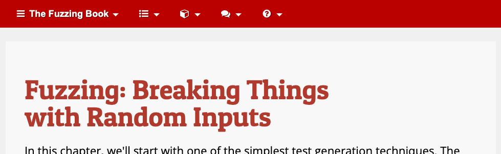

```python
Image(gui_driver.get_screenshot_as_png())
```

```python
book_runner = GUIRunner(gui_driver)
```

```python
book_fuzzer = GUICoverageFuzzer(gui_driver, log_gui_exploration=True)  # , disp_gui_exploration=True)
```

We explore the first few states of the site, defined in `ACTIONS`:

```python
ACTIONS = 5
```

```python
book_fuzzer.explore_all(book_runner, max_actions=ACTIONS)
```

```
Run #1
```

```
Action click('use the code provided in this chapter') -> <state-6>
```

```
In new state <state-6> frozenset({"click('the chapter on fuzzers')", "ignore('Pipenv')", "click('Fuzzer')", "ignore('requirements.txt file within the project root folder')", "ignore('official instructions')", "ignore('Creative Commons Attribution-NonCommercial-ShareAlike 4.0 International License')"…
```

```
Run #2
```

```
Action click('use grammars to specify the input format and thus get many more valid inputs') -> <state-1>
```

```
In new state <state-1> frozenset({"click('Fuzzer')", "click('grammar toolbox')", "click('coverage-based')", "click('probabilities')", "click('create an efficient grammar fuzzer')", "click('The Fuzzing Book')", "click('fuzz configurations')", "ignore('CSmith')", "click('use the code provided in this …
```

```
Run #3
```

```
Action click('chapter on mining function specifications') -> <state-14>
```

```
In new state <state-14> frozenset({"click('introduction to testing')", "ignore('DAIKON dynamic invariant detector')", "ignore('Use the notebook')", "ignore('code snippet from StackOverflow')", "ignore('Ammons et al, 2002')", "ignore('MIT License')", "ignore('')", "click('The Fuzzing Book')", "click(…
```

```
Run #4
```

```
Action click('Introduction to Testing') -> <state-16>
```

```
In new state <state-16> frozenset({"ignore('Use the notebook')", "ignore('Myers et al, 2004')", "ignore('&quot;Effective Software Testing: A Developer&#x27;s Guide&quot;')", "ignore('MIT License')", "ignore('')", "click('The Fuzzing Book')", "click('Background')", "click('Cite')", "ignore('bookutils…
```

```
Run #5
```

```
Action click('ExpectError') -> <state-8>
```

```
In existing state <state>
Replacing expected state <state-8> by <state>
```

After the first `ACTIONS` actions already, we can see that the finite state model is quite complex, with dozens of transitions still left to explore. Most of the yet unexplored states will eventually merge with existing states, yielding one state per chapter. Still, following *all* links on *all* pages will take quite some time.

```python
# Inspect this graph in the notebook to see it in full glory
fsm_diagram(book_fuzzer.grammar)
```

[output not shown]

[output cut: 69 more lines]

[output not shown]

```
<graphviz.graphs.Digraph at 0x10f736360>
```

We now have all the basic capabilities we need: We can automatically explore large websites; we can explore "deep" functionality by filling out forms; and we can have our coverage-based fuzzer automatically focus on yet unexplored states. Still, there is a lot more one can do; the exercises will give you some ideas.

```python
gui_driver.quit()
```

## Lessons Learned

- *Selenium* is a powerful framework for interacting with user interfaces, especially Web-based user interfaces.
- A *finite state model* can encode user interface states and transitions.
- Encoding user interface models into a *grammar* integrates generating text (for forms) and generating user interactions (for navigating)
- To systematically explore a user interface, cover all *state transitions*, which is equivalent to covering all *expansion alternatives* in the equivalent grammar.

We are done, so we clean up. We shut down our Web server, quit the Web driver (and the associated browser), and finally clean up temporary files left by Selenium.

```python
httpd_process.terminate()
```

```python
gui_driver.quit()
```

```python
for temp_file in [ORDERS_DB, "geckodriver.log", "ghostdriver.log"]:
    if os.path.exists(temp_file):
        os.remove(temp_file)
```

## Next Steps

From here, you can learn how to

- fuzz in the large. running a myriad of fuzzers on the same system

## Background

Automatic testing of graphical user interfaces is a rich field – in research as in practice.

Coverage criteria for GUIs as well as how to achieve them were first discussed in \cite{Memon2001}. Memon also introduced the concept of *GUI Ripping* \cite{Memon2003} – the process in which the software's GUI is automatically traversed by interacting with all its user interface elements.

The CrawlJax tool \cite{Mesbah2012} uses dynamic state changes in Web user interfaces to identify candidate elements to interact with. As our approach above, it uses the set of interactable user interface elements as a state in a finite-state model.

The [Alex framework](https://learnlib.github.io/alex/) uses a similar approach to learn automata for web applications. Starting from a set of test inputs, it produces a mixed-mode behavioral model of the application.

## Exercises

As powerful as our GUI fuzzer is at this point, there are still several possibilities left for further optimization and extension. Here are some ideas to get you started. Enjoy user interface fuzzing!

### Exercise 1: Stay in Local State

Rather than having each `run()` start at the very beginning, have the miner start from the current state and explore states reachable from there.

### Exercise 2: Going Back

Make use of the web driver `back()` method and go back to an earlier state, from which we could again start exploration. (Note that a "back" functionality may not be available on non-Web user interfaces.)

### Exercise 3: Avoiding Bad Form Values

Detect that some form values are *invalid*, such that the miner does not produce them again.

### Exercise 4: Saving Form Values

Save *successful* form values, such that the tester does not have to infer them again and again.

### Exercise 5: Same Names, Same States

When the miner finds a link with a name it has already seen, it is likely to lead to a state already seen, too; therefore, one could give its exploration a lower priority.

### Exercise 6: Combinatorial Coverage

Extend the grammar miner such that for every boolean value, there is a separate value to be covered.

### Exercise 7: Implicit Delays

Rather than using *explicit* (given) delays, use *implicit* delays and wait for specific elements to appear. these elements could stem from previous explorations of the state.

### Exercise 8: Oracles

Extend the grammar miner such that it also produces *oracles* – for instance, checking for the presence of specific UI elements.

### Exercise 9: More UI Elements

Run the miner on a website of your choice. Find out which other types of user interface elements and actions need to be supported.